# **Project 1: Defining a Problem and Data Understanding**

## Section 2.2: Genre Preferences by Country of Origin.

We will now visualize the genre preferences by country of origin using a Grouped Bar Plot.

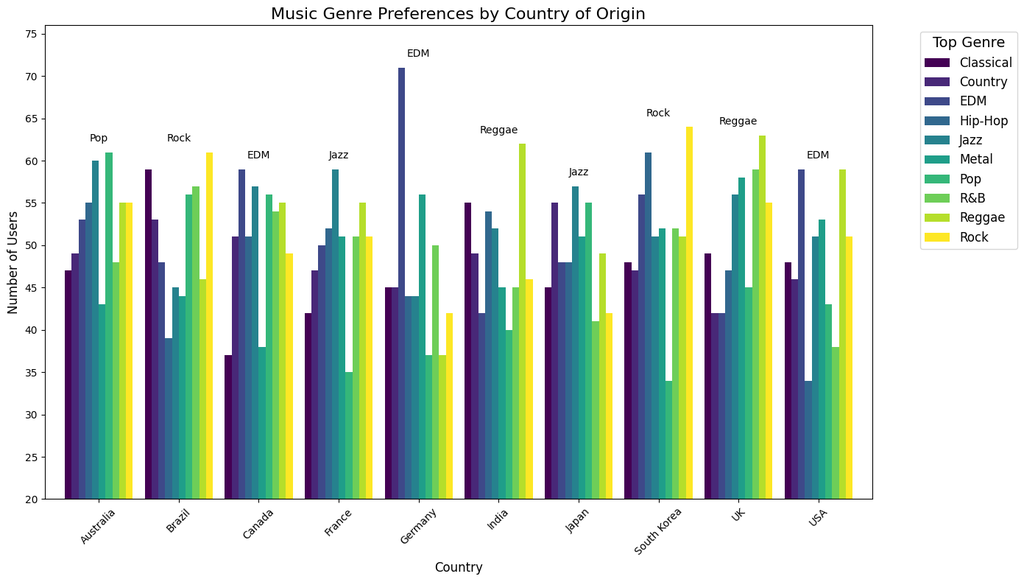

```python
# Group the data by country and genre to count the number of users in each genre per country
country_genre_counts = music_data.groupby(['Country', 'Top Genre']).size().reset_index(name='User_Count')

# Pivot the data to make genres columns for easier plotting
pivot_data = country_genre_counts.pivot(index='Country', columns='Top Genre', values='User_Count').fillna(0)

# Plot the grouped bar plot
ax = pivot_data.plot(kind='bar', figsize=(14, 8), colormap='viridis', width=0.85)

# Calculate the top genre for each country
top_genres = pivot_data.idxmax(axis=1)  # Get the top genre for each country
top_values = pivot_data.max(axis=1)    # Get the corresponding user count for the top genre

# Annotate the top genre on the bar chart
for i, country in enumerate(pivot_data.index):
    ax.text(i, top_values[country] + 1,  # Position the text slightly above the bar
            f'{top_genres[country]}',    # Label with the top genre
            ha='center', va='bottom', fontsize=10, color='black')

max_value= int(top_values.max())
plt.yticks(np.arange(20, max_value +5,5))
plt.ylim(20, max_value + 5)

# Titles and labels
plt.title('Music Genre Preferences by Country of Origin', fontsize=16)
plt.xlabel('Country', fontsize=12)
plt.ylabel('Number of Users', fontsize=12)

# Customize the legend
plt.legend(title='Top Genre', bbox_to_anchor=(1.05, 1), loc='upper left', fontsize=12, title_fontsize=14)

# Rotate x-axis labels for better readability
plt.xticks(rotation=45)
plt.tight_layout()

# Show the plot
plt.show()
```

## Results of Data Visualization 2.2

After creating our grouped bar chart to help determine the top genre of each of the countries. I am a little shocked to some of the results I found. From growing up constantly listening to the radio when in the car with my parents because they were not up to the times with streaming music, a lot of the music that I would hear in the "Top 10's" and "Billboard 100's" would be primarily pop songs so seeing that the top genre for the USA is actually EDM is suprising to me. Granted there are only 5k users data within this file so that could certainly skew the overall results, but even from looking through the data set and seeing some of the top artists that are listed throughout the data set the genre that these artists are primarily known for do not correlate to the preferred genre for their country of origin.

- **NOTE** This dataset is small (5000 users) with only 10 countries listed. Along with only baseline genres being and not including niche genres, these results may not be completely accurate compared to the overall listening preferences of the world.